# Ad Hoc Analysis (keiba)

作成日時: 2019/11/07 08:54:59

# 1. 1変数決定木

## 1-a. 樹形図

### 【ptn001_馬番】

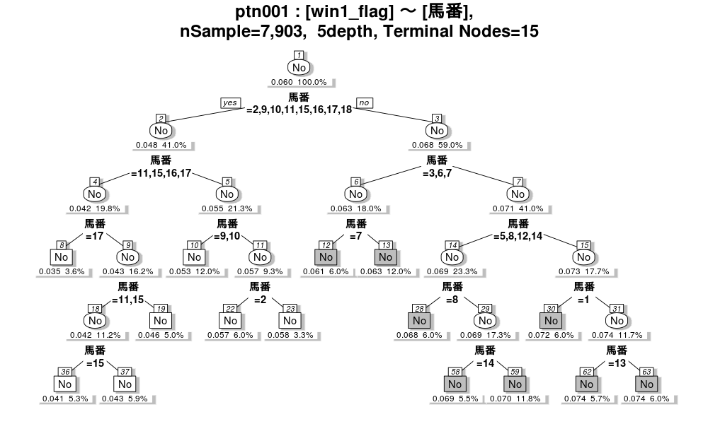

### 【ptn002_枠番】

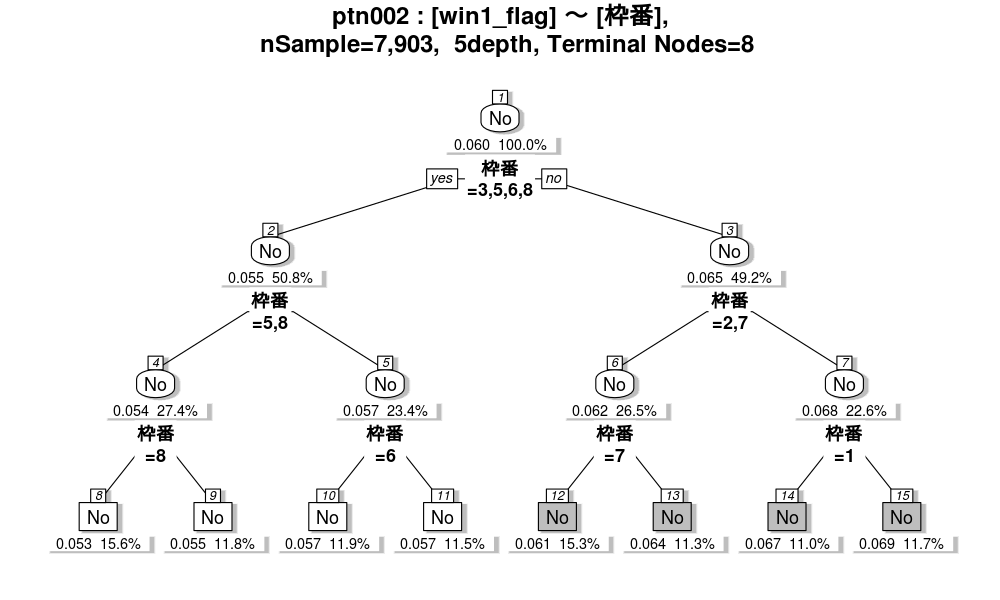

### 【ptn003_開催地】

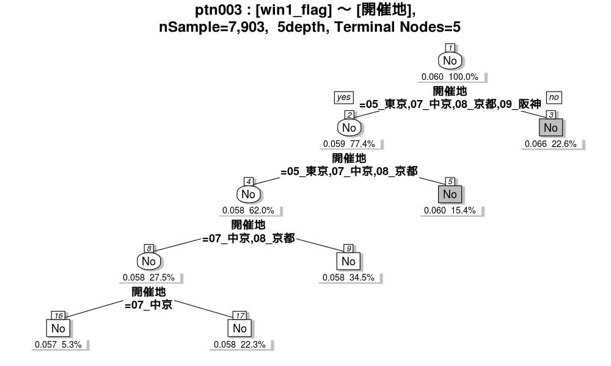

### 【ptn004_開催年】

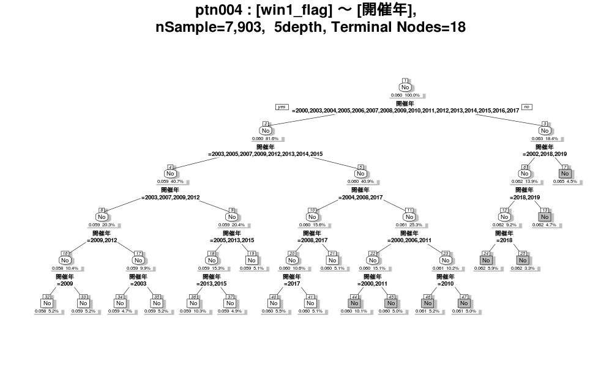

### 【ptn005_開催月】

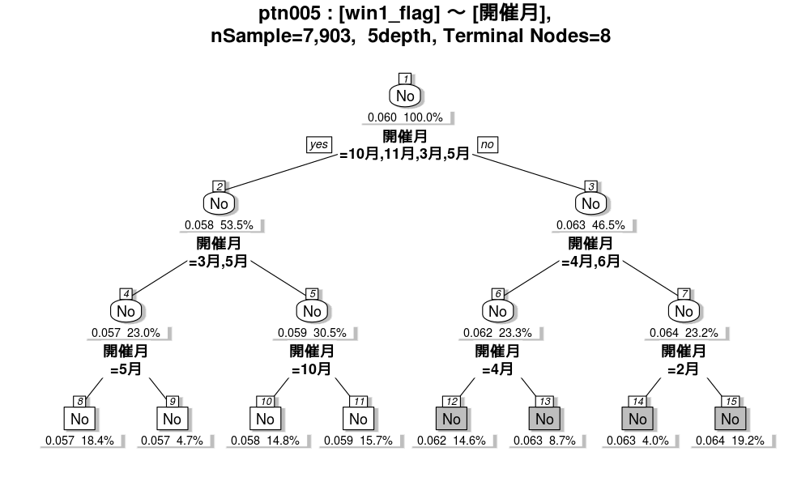

### 【ptn006_距離】

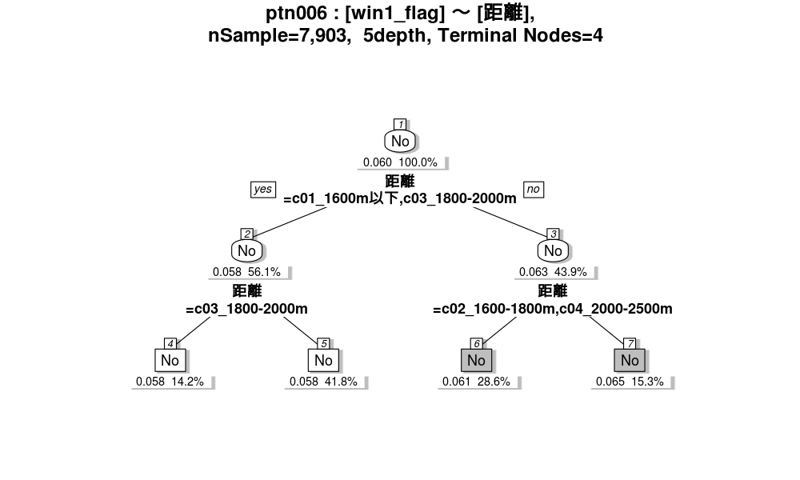

### 【ptn007_右-左周り】

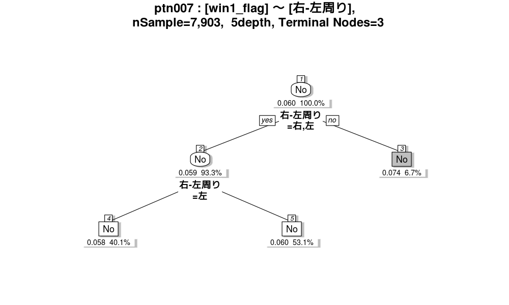

### 【ptn008_天候】

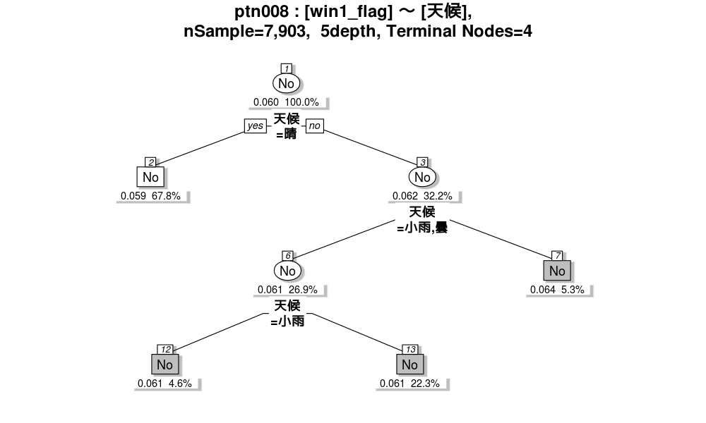

### 【ptn009_芝-ダート】

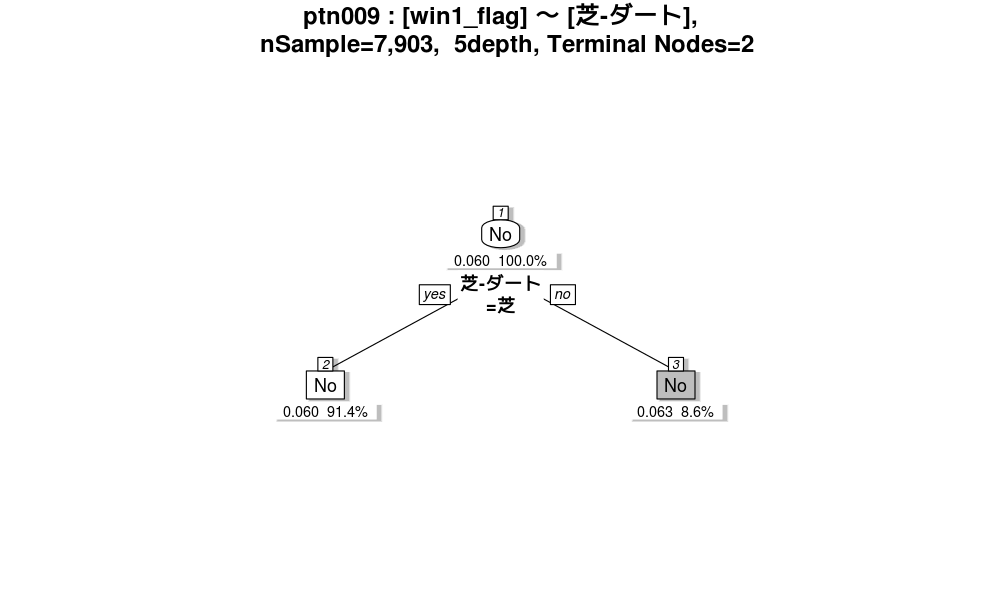

### 【ptn010_コンディション】

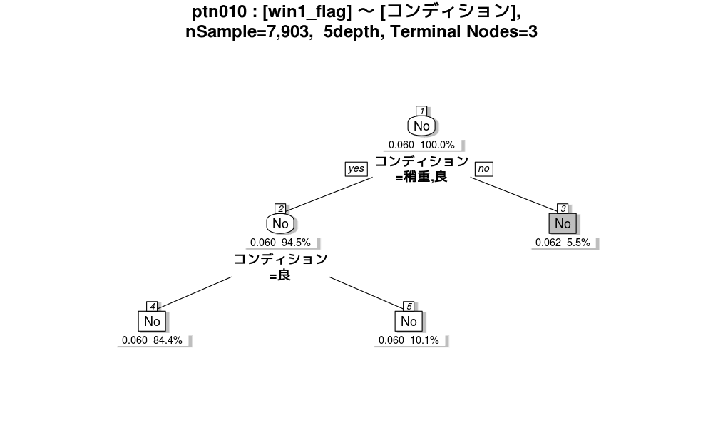

## 1-b. 決定木ルール

### 【ptn001_馬番】

**ptn001 : [win1_flag] ～ [馬番], nSample=7,903, 5depth, Terminal Nodes=15**

| No | 【Terminal NodeID】: 決定木ルール | 確率(%) | リフト値 | サンプル数 | 構成比(%) |
| --- | --- | --- | --- | --- | --- |
| 1 | 【63】: [馬番=4] | 7.4 | 1.23 | 474 | 6.0 |
| 2 | 【62】: [馬番=13] | 7.4 | 1.23 | 447 | 5.7 |
| 3 | 【30】: [馬番=1] | 7.2 | 1.19 | 474 | 6.0 |
| 4 | 【59】: [馬番=5,12] | 7.0 | 1.16 | 935 | 11.8 |
| 5 | 【58】: [馬番=14] | 6.9 | 1.15 | 434 | 5.5 |
| 6 | 【28】: [馬番=8] | 6.8 | 1.12 | 474 | 6.0 |
| 7 | 【13】: [馬番=3,6] | 6.3 | 1.05 | 948 | 12.0 |
| 8 | 【12】: [馬番=7] | 6.1 | 1.02 | 474 | 6.0 |
| 9 | 【23】: [馬番=18] | 5.8 | 0.96 | 259 | 3.3 |
| 10 | 【22】: [馬番=2] | 5.7 | 0.95 | 474 | 6.0 |

[output cut: 5 more lines]

### 【ptn002_枠番】

**ptn002 : [win1_flag] ～ [枠番], nSample=7,903, 5depth, Terminal Nodes=8**

| No | 【Terminal NodeID】: 決定木ルール | 確率(%) | リフト値 | サンプル数 | 構成比(%) |
| --- | --- | --- | --- | --- | --- |
| 1 | 【15】: [枠番=4] | 6.9 | 1.16 | 921 | 11.7 |
| 2 | 【14】: [枠番=1] | 6.7 | 1.11 | 867 | 11.0 |
| 3 | 【13】: [枠番=2] | 6.4 | 1.06 | 891 | 11.3 |
| 4 | 【12】: [枠番=7] | 6.1 | 1.02 | 1,207 | 15.3 |
| 5 | 【11】: [枠番=3] | 5.7 | 0.95 | 908 | 11.5 |
| 6 | 【10】: [枠番=6] | 5.7 | 0.95 | 943 | 11.9 |
| 7 | 【9】: [枠番=5] | 5.5 | 0.91 | 935 | 11.8 |
| 8 | 【8】: [枠番=8] | 5.3 | 0.88 | 1,231 | 15.6 |

### 【ptn003_開催地】

**ptn003 : [win1_flag] ～ [開催地], nSample=7,903, 5depth, Terminal Nodes=5**

| No | 【Terminal NodeID】: 決定木ルール | 確率(%) | リフト値 | サンプル数 | 構成比(%) |
| --- | --- | --- | --- | --- | --- |
| 1 | 【3】: [開催地=04_新潟,06_中山] | 6.6 | 1.09 | 1,786 | 22.6 |
| 2 | 【5】: [開催地=09_阪神] | 6.0 | 1.00 | 1,214 | 15.4 |
| 3 | 【9】: [開催地=05_東京] | 5.8 | 0.97 | 2,726 | 34.5 |
| 4 | 【17】: [開催地=08_京都] | 5.8 | 0.96 | 1,759 | 22.3 |
| 5 | 【16】: [開催地=07_中京] | 5.7 | 0.96 | 418 | 5.3 |

### 【ptn004_開催年】

**ptn004 : [win1_flag] ～ [開催年], nSample=7,903, 5depth, Terminal Nodes=18**

| No | 【Terminal NodeID】: 決定木ルール | 確率(%) | リフト値 | サンプル数 | 構成比(%) |
| --- | --- | --- | --- | --- | --- |
| 1 | 【7】: [開催年=2001] | 6.5 | 1.07 | 356 | 4.5 |
| 2 | 【13】: [開催年=2002] | 6.2 | 1.04 | 369 | 4.7 |
| 3 | 【25】: [開催年=2019] | 6.2 | 1.03 | 258 | 3.3 |
| 4 | 【24】: [開催年=2018] | 6.2 | 1.03 | 469 | 5.9 |
| 5 | 【47】: [開催年=2016] | 6.1 | 1.01 | 395 | 5.0 |
| 6 | 【46】: [開催年=2010] | 6.1 | 1.01 | 412 | 5.2 |
| 7 | 【45】: [開催年=2006] | 6.0 | 1.01 | 397 | 5.0 |
| 8 | 【44】: [開催年=2000,2011] | 6.0 | 1.00 | 795 | 10.1 |
| 9 | 【21】: [開催年=2004] | 6.0 | 1.00 | 400 | 5.1 |
| 10 | 【41】: [開催年=2008] | 6.0 | 1.00 | 401 | 5.1 |

[output cut: 8 more lines]

### 【ptn005_開催月】

**ptn005 : [win1_flag] ～ [開催月], nSample=7,903, 5depth, Terminal Nodes=8**

| No | 【Terminal NodeID】: 決定木ルール | 確率(%) | リフト値 | サンプル数 | 構成比(%) |
| --- | --- | --- | --- | --- | --- |
| 1 | 【15】: [開催月=12月,1月,7月,9月] | 6.4 | 1.06 | 1,516 | 19.2 |
| 2 | 【14】: [開催月=2月] | 6.3 | 1.05 | 317 | 4.0 |
| 3 | 【13】: [開催月=6月] | 6.3 | 1.04 | 688 | 8.7 |
| 4 | 【12】: [開催月=4月] | 6.2 | 1.02 | 1,153 | 14.6 |
| 5 | 【11】: [開催月=11月] | 5.9 | 0.98 | 1,237 | 15.7 |
| 6 | 【10】: [開催月=10月] | 5.8 | 0.97 | 1,171 | 14.8 |
| 7 | 【9】: [開催月=3月] | 5.7 | 0.94 | 370 | 4.7 |
| 8 | 【8】: [開催月=5月] | 5.7 | 0.94 | 1,451 | 18.4 |

### 【ptn006_距離】

**ptn006 : [win1_flag] ～ [距離], nSample=7,903, 5depth, Terminal Nodes=4**

| No | 【Terminal NodeID】: 決定木ルール | 確率(%) | リフト値 | サンプル数 | 構成比(%) |
| --- | --- | --- | --- | --- | --- |
| 1 | 【7】: [距離=c05_3000m以上] | 6.5 | 1.09 | 1,211 | 15.3 |
| 2 | 【6】: [距離=c02_1600-1800m,c04_2000-2500m] | 6.1 | 1.02 | 2,261 | 28.6 |
| 3 | 【5】: [距離=c01_1600m以下] | 5.8 | 0.97 | 3,305 | 41.8 |
| 4 | 【4】: [距離=c03_1800-2000m] | 5.8 | 0.96 | 1,126 | 14.2 |

### 【ptn007_右-左周り】

**ptn007 : [win1_flag] ～ [右-左周り], nSample=7,903, 5depth, Terminal Nodes=3**

| No | 【Terminal NodeID】: 決定木ルール | 確率(%) | リフト値 | サンプル数 | 構成比(%) |
| --- | --- | --- | --- | --- | --- |
| 1 | 【3】: [右-左周り=直線] | 7.4 | 1.22 | 530 | 6.7 |
| 2 | 【5】: [右-左周り=右] | 6.0 | 0.99 | 4,200 | 53.1 |
| 3 | 【4】: [右-左周り=左] | 5.8 | 0.97 | 3,173 | 40.1 |

### 【ptn008_天候】

**ptn008 : [win1_flag] ～ [天候], nSample=7,903, 5depth, Terminal Nodes=4**

| No | 【Terminal NodeID】: 決定木ルール | 確率(%) | リフト値 | サンプル数 | 構成比(%) |
| --- | --- | --- | --- | --- | --- |
| 1 | 【7】: [天候=雨] | 6.4 | 1.06 | 422 | 5.3 |
| 2 | 【13】: [天候=曇] | 6.1 | 1.02 | 1,763 | 22.3 |
| 3 | 【12】: [天候=小雨] | 6.1 | 1.01 | 362 | 4.6 |
| 4 | 【2】: [天候=晴] | 5.9 | 0.99 | 5,356 | 67.8 |

### 【ptn009_芝-ダート】

**ptn009 : [win1_flag] ～ [芝-ダート], nSample=7,903, 5depth, Terminal Nodes=2**

| No | 【Terminal NodeID】: 決定木ルール | 確率(%) | リフト値 | サンプル数 | 構成比(%) |
| --- | --- | --- | --- | --- | --- |
| 1 | 【3】: [芝-ダート=ダート] | 6.3 | 1.05 | 681 | 8.6 |
| 2 | 【2】: [芝-ダート=芝] | 6.0 | 1.00 | 7,222 | 91.4 |

### 【ptn010_コンディション】

**ptn010 : [win1_flag] ～ [コンディション], nSample=7,903, 5depth, Terminal Nodes=3**

| No | 【Terminal NodeID】: 決定木ルール | 確率(%) | リフト値 | サンプル数 | 構成比(%) |
| --- | --- | --- | --- | --- | --- |
| 1 | 【3】: [コンディション=不良,重] | 6.2 | 1.03 | 436 | 5.5 |
| 2 | 【5】: [コンディション=稍重] | 6.0 | 1.00 | 799 | 10.1 |
| 3 | 【4】: [コンディション=良] | 6.0 | 1.00 | 6,668 | 84.4 |

# 2. 2変数決定木

## 2-a. 樹形図

### 【ptn001_馬番_枠番】

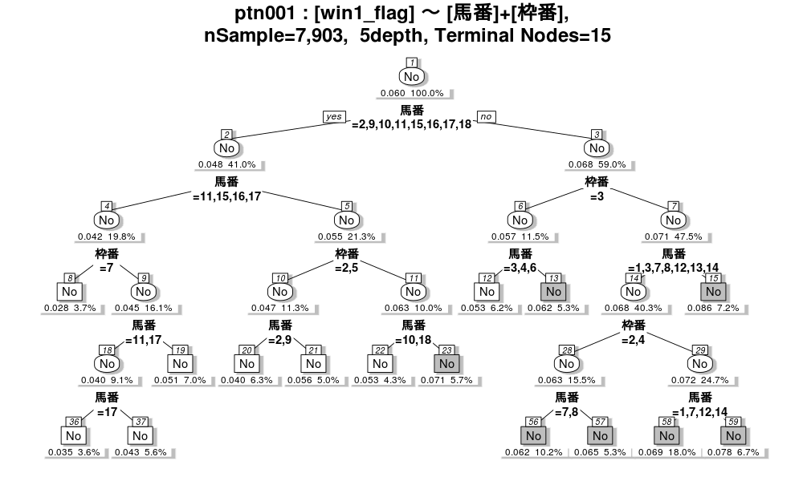

### 【ptn002_馬番_開催地】

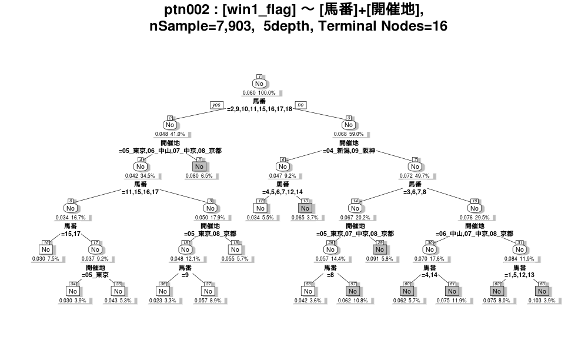

### 【ptn003_馬番_開催年】

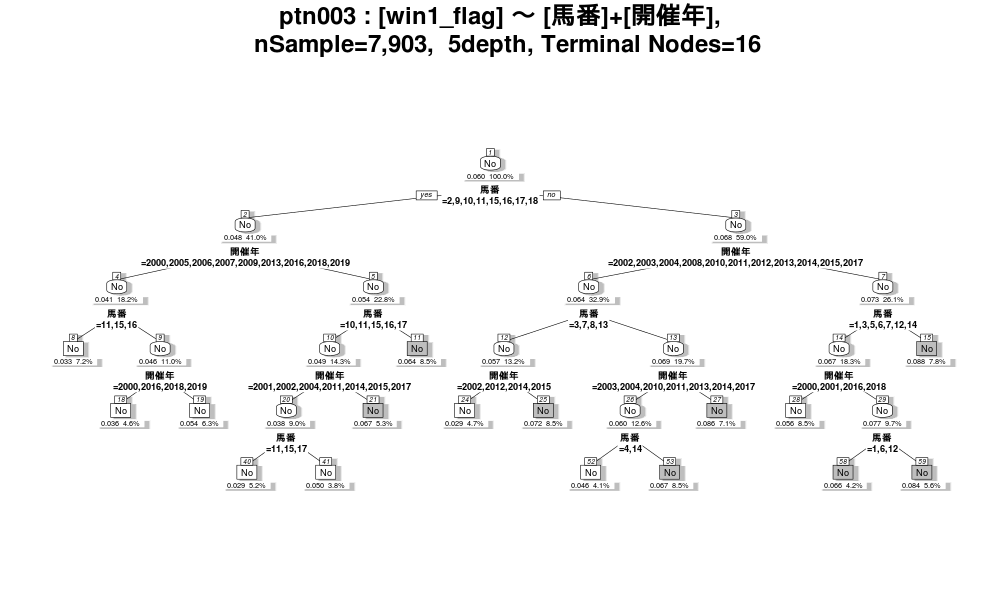

### 【ptn004_馬番_開催月】

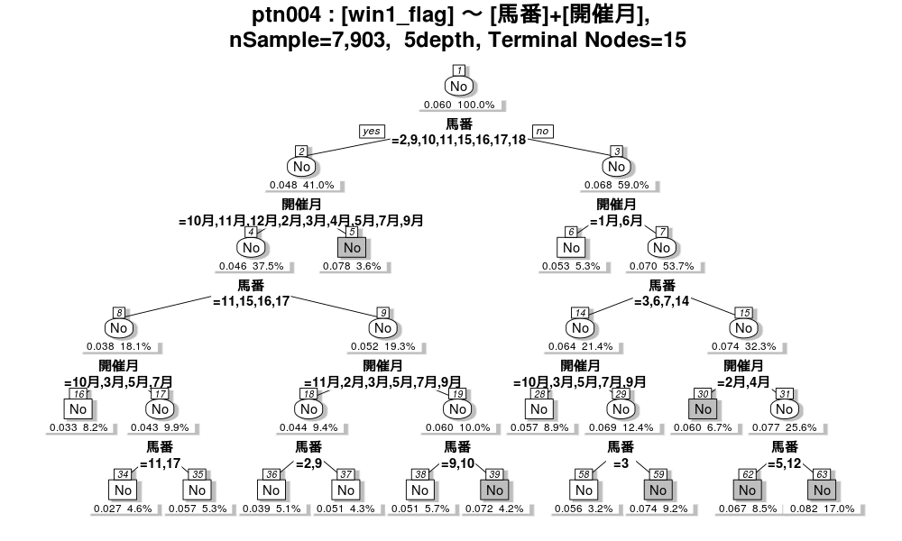

### 【ptn005_馬番_距離】

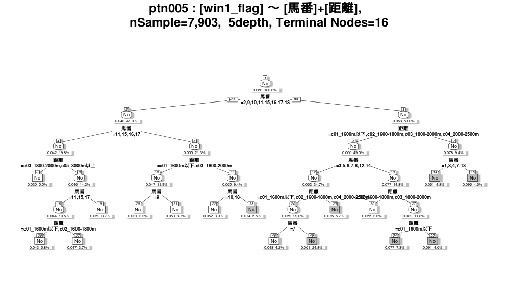

### 【ptn006_馬番_右-左周り】

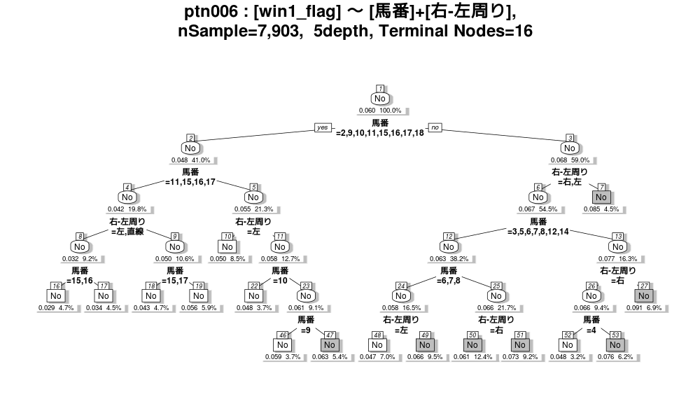

### 【ptn007_馬番_天候】

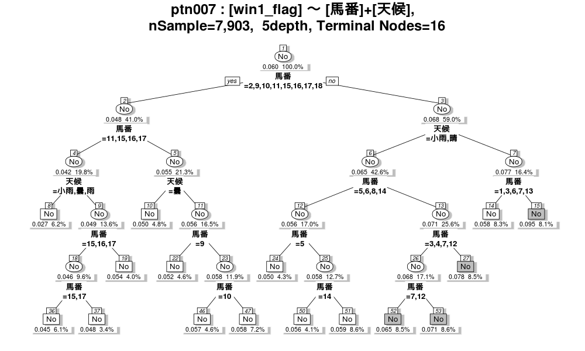

### 【ptn008_馬番_芝-ダート】

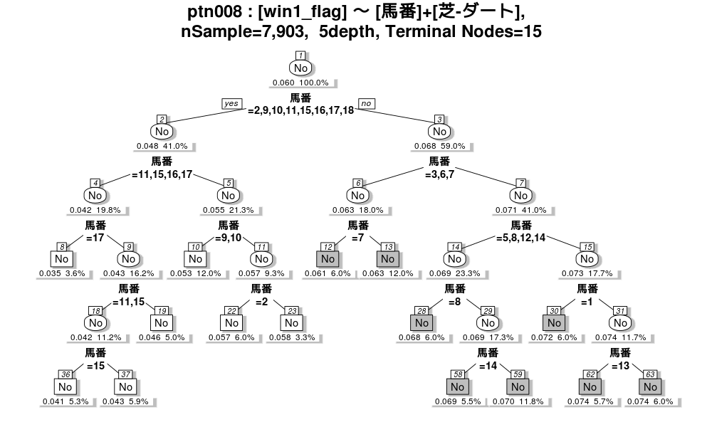

### 【ptn009_馬番_コンディション】

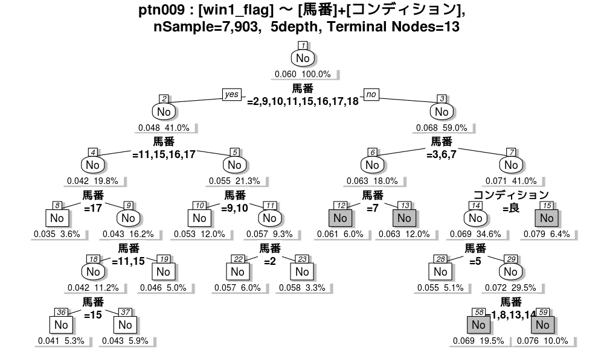

## 2-b. 決定木ルール

### 【ptn001_馬番_枠番】

**ptn001 : [win1_flag] ～ [馬番]+[枠番], nSample=7,903, 5depth, Terminal Nodes=15**

| No | 【Terminal NodeID】: 決定木ルール | 確率(%) | リフト値 | サンプル数 | 構成比(%) |
| --- | --- | --- | --- | --- | --- |
| 1 | 【15】: [馬番=4,5,6] & [枠番=1,2,4,5,6,7,8] | 8.6 | 1.43 | 571 | 7.2 |
| 2 | 【59】: [馬番=8,13] & [枠番=1,5,6,7,8] | 7.8 | 1.29 | 528 | 6.7 |
| 3 | 【23】: [馬番=2,9] & [枠番=1,6,7,8] | 7.1 | 1.18 | 450 | 5.7 |
| 4 | 【58】: [馬番=1,7,12,14] & [枠番=1,5,6,7,8] | 6.9 | 1.16 | 1,426 | 18.0 |
| 5 | 【57】: [馬番=3] & [枠番=2,4] | 6.5 | 1.08 | 417 | 5.3 |
| 6 | 【13】: [馬番=5] & [枠番=3] | 6.2 | 1.04 | 417 | 5.3 |
| 7 | 【56】: [馬番=7,8] & [枠番=2,4] | 6.2 | 1.03 | 810 | 10.2 |
| 8 | 【21】: [馬番=10] & [枠番=2,5] | 5.6 | 0.93 | 393 | 5.0 |
| 9 | 【12】: [馬番=3,4,6] & [枠番=3] | 5.3 | 0.88 | 491 | 6.2 |
| 10 | 【22】: [馬番=10,18] & [枠番=1,6,7,8] | 5.3 | 0.88 | 340 | 4.3 |

[output cut: 5 more lines]

### 【ptn002_馬番_開催地】

**ptn002 : [win1_flag] ～ [馬番]+[開催地], nSample=7,903, 5depth, Terminal Nodes=16**

| No | 【Terminal NodeID】: 決定木ルール | 確率(%) | リフト値 | サンプル数 | 構成比(%) |
| --- | --- | --- | --- | --- | --- |
| 1 | 【63】: [馬番=4,14] & [開催地=05_東京] | 10.3 | 1.71 | 312 | 3.9 |
| 2 | 【29】: [馬番=3,6,7,8] & [開催地=06_中山] | 9.1 | 1.52 | 460 | 5.8 |
| 3 | 【5】: [馬番=2,9,10,11,15,16,17,18] & [開催地=04_新潟,09_阪神] | 8.0 | 1.33 | 513 | 6.5 |
| 4 | 【62】: [馬番=1,5,12,13] & [開催地=05_東京] | 7.5 | 1.24 | 629 | 8.0 |
| 5 | 【61】: [馬番=1,5,12,13] & [開催地=06_中山,07_中京,08_京都] | 7.5 | 1.24 | 939 | 11.9 |
| 6 | 【13】: [馬番=1,3,8,13] & [開催地=04_新潟,09_阪神] | 6.5 | 1.08 | 292 | 3.7 |
| 7 | 【57】: [馬番=3,6,7] & [開催地=05_東京,07_中京,08_京都] | 6.2 | 1.03 | 852 | 10.8 |
| 8 | 【60】: [馬番=4,14] & [開催地=06_中山,07_中京,08_京都] | 6.2 | 1.03 | 454 | 5.7 |
| 9 | 【37】: [馬番=2,10,18] & [開催地=05_東京,08_京都] | 5.7 | 0.95 | 700 | 8.9 |
| 10 | 【19】: [馬番=2,9,10,18] & [開催地=06_中山,07_中京] | 5.5 | 0.92 | 452 | 5.7 |

[output cut: 6 more lines]

### 【ptn003_馬番_開催年】

**ptn003 : [win1_flag] ～ [馬番]+[開催年], nSample=7,903, 5depth, Terminal Nodes=16**

| No | 【Terminal NodeID】: 決定木ルール | 確率(%) | リフト値 | サンプル数 | 構成比(%) |
| --- | --- | --- | --- | --- | --- |
| 1 | 【15】: [馬番=4,8,13] & [開催年=2000,2001,2005,2006,2007,2009,2016,2018,2019] | 8.8 | 1.46 | 616 | 7.8 |
| 2 | 【27】: [馬番=1,4,5,6,12,14] & [開催年=2002,2008,2012,2015] | 8.6 | 1.43 | 560 | 7.1 |
| 3 | 【59】: [馬番=3,5,7,14] & [開催年=2005,2006,2007,2009,2019] | 8.4 | 1.40 | 439 | 5.6 |
| 4 | 【25】: [馬番=3,7,8,13] & [開催年=2003,2004,2008,2010,2011,2013,2017] | 7.2 | 1.19 | 669 | 8.5 |
| 5 | 【53】: [馬番=1,5,6,12] & [開催年=2003,2004,2010,2011,2013,2014,2017] | 6.7 | 1.11 | 672 | 8.5 |
| 6 | 【21】: [馬番=10,11,15,16,17] & [開催年=2003,2008,2010,2012] | 6.7 | 1.11 | 419 | 5.3 |
| 7 | 【58】: [馬番=1,6,12] & [開催年=2005,2006,2007,2009,2019] | 6.6 | 1.11 | 331 | 4.2 |
| 8 | 【11】: [馬番=2,9,18] & [開催年=2001,2002,2003,2004,2008,2010,2011,2012,2014,2015,2017] | 6.4 | 1.06 | 674 | 8.5 |
| 9 | 【28】: [馬番=1,3,5,6,7,12,14] & [開催年=2000,2001,2016,2018] | 5.6 | 0.94 | 673 | 8.5 |
| 10 | 【19】: [馬番=2,9,10,17,18] & [開催年=2005,2006,2007,2009,2013] | 5.4 | 0.90 | 500 | 6.3 |

[output cut: 6 more lines]

### 【ptn004_馬番_開催月】

**ptn004 : [win1_flag] ～ [馬番]+[開催月], nSample=7,903, 5depth, Terminal Nodes=15**

| No | 【Terminal NodeID】: 決定木ルール | 確率(%) | リフト値 | サンプル数 | 構成比(%) |
| --- | --- | --- | --- | --- | --- |
| 1 | 【63】: [馬番=1,4,8,13] & [開催月=10月,11月,12月,3月,5月,7月,9月] | 8.2 | 1.37 | 1,346 | 17.0 |
| 2 | 【5】: [馬番=2,9,10,11,15,16,17,18] & [開催月=1月,6月] | 7.8 | 1.30 | 282 | 3.6 |
| 3 | 【59】: [馬番=6,7,14] & [開催月=11月,12月,2月,4月] | 7.4 | 1.23 | 731 | 9.2 |
| 4 | 【39】: [馬番=2,18] & [開催月=10月,12月,4月] | 7.2 | 1.20 | 333 | 4.2 |
| 5 | 【62】: [馬番=5,12] & [開催月=10月,11月,12月,3月,5月,7月,9月] | 6.7 | 1.11 | 674 | 8.5 |
| 6 | 【30】: [馬番=1,4,5,8,12,13] & [開催月=2月,4月] | 6.0 | 1.00 | 531 | 6.7 |
| 7 | 【35】: [馬番=15,16] & [開催月=11月,12月,2月,4月,9月] | 5.7 | 0.95 | 420 | 5.3 |
| 8 | 【28】: [馬番=3,6,7,14] & [開催月=10月,3月,5月,7月,9月] | 5.7 | 0.94 | 707 | 8.9 |
| 9 | 【58】: [馬番=3] & [開催月=11月,12月,2月,4月] | 5.6 | 0.92 | 252 | 3.2 |
| 10 | 【6】: [馬番=1,3,4,5,6,7,8,12,13,14] & [開催月=1月,6月] | 5.3 | 0.87 | 419 | 5.3 |

[output cut: 5 more lines]

### 【ptn005_馬番_距離】

**ptn005 : [win1_flag] ～ [馬番]+[距離], nSample=7,903, 5depth, Terminal Nodes=16**

| No | 【Terminal NodeID】: 決定木ルール | 確率(%) | リフト値 | サンプル数 | 構成比(%) |
| --- | --- | --- | --- | --- | --- |
| 1 | 【15】: [馬番=5,6,8,12,14] & [距離=c05_3000m以上] | 9.6 | 1.60 | 365 | 4.6 |
| 2 | 【55】: [馬番=1,4,13] & [距離=c04_2000-2500m] | 9.1 | 1.51 | 363 | 4.6 |
| 3 | 【54】: [馬番=1,4,13] & [距離=c01_1600m以下] | 7.7 | 1.28 | 573 | 7.3 |
| 4 | 【25】: [馬番=3,5,6,7,8,12,14] & [距離=c03_1800-2000m] | 7.5 | 1.25 | 452 | 5.7 |
| 5 | 【23】: [馬番=2,9] & [距離=c02_1600-1800m,c04_2000-2500m,c05_3000m以上] | 7.4 | 1.23 | 434 | 5.5 |
| 6 | 【49】: [馬番=3,5,6,8,12,14] & [距離=c01_1600m以下,c02_1600-1800m,c04_2000-2500m] | 6.1 | 1.02 | 1,960 | 24.8 |
| 7 | 【14】: [馬番=1,3,4,7,13] & [距離=c05_3000m以上] | 6.1 | 1.01 | 380 | 4.8 |
| 8 | 【26】: [馬番=1,4,13] & [距離=c02_1600-1800m,c03_1800-2000m] | 5.5 | 0.91 | 237 | 3.0 |
| 9 | 【21】: [馬番=2,10,18] & [距離=c01_1600m以下,c03_1800-2000m] | 5.3 | 0.87 | 685 | 8.7 |
| 10 | 【22】: [馬番=10,18] & [距離=c02_1600-1800m,c04_2000-2500m,c05_3000m以上] | 5.2 | 0.87 | 305 | 3.9 |

[output cut: 6 more lines]

### 【ptn006_馬番_右-左周り】

**ptn006 : [win1_flag] ～ [馬番]+[右-左周り], nSample=7,903, 5depth, Terminal Nodes=16**

| No | 【Terminal NodeID】: 決定木ルール | 確率(%) | リフト値 | サンプル数 | 構成比(%) |
| --- | --- | --- | --- | --- | --- |
| 1 | 【27】: [馬番=1,4,13] & [右-左周り=左] | 9.1 | 1.52 | 549 | 6.9 |
| 2 | 【7】: [馬番=1,3,4,5,6,7,8,12,13,14] & [右-左周り=直線] | 8.5 | 1.41 | 353 | 4.5 |
| 3 | 【53】: [馬番=1,13] & [右-左周り=右] | 7.6 | 1.26 | 490 | 6.2 |
| 4 | 【51】: [馬番=3,5,12,14] & [右-左周り=左] | 7.3 | 1.21 | 729 | 9.2 |
| 5 | 【49】: [馬番=6,7,8] & [右-左周り=右] | 6.6 | 1.10 | 753 | 9.5 |
| 6 | 【47】: [馬番=2,18] & [右-左周り=右,直線] | 6.3 | 1.05 | 426 | 5.4 |
| 7 | 【50】: [馬番=3,5,12,14] & [右-左周り=右] | 6.1 | 1.02 | 983 | 12.4 |
| 8 | 【46】: [馬番=9] & [右-左周り=右,直線] | 5.9 | 0.98 | 290 | 3.7 |
| 9 | 【19】: [馬番=11,16] & [右-左周り=右] | 5.6 | 0.93 | 464 | 5.9 |
| 10 | 【10】: [馬番=2,9,10,18] & [右-左周り=左] | 5.0 | 0.84 | 675 | 8.5 |

[output cut: 6 more lines]

### 【ptn007_馬番_天候】

**ptn007 : [win1_flag] ～ [馬番]+[天候], nSample=7,903, 5depth, Terminal Nodes=16**

| No | 【Terminal NodeID】: 決定木ルール | 確率(%) | リフト値 | サンプル数 | 構成比(%) |
| --- | --- | --- | --- | --- | --- |
| 1 | 【15】: [馬番=4,5,8,12,14] & [天候=曇,雨] | 9.5 | 1.58 | 641 | 8.1 |
| 2 | 【27】: [馬番=1,13] & [天候=小雨,晴] | 7.8 | 1.29 | 670 | 8.5 |
| 3 | 【53】: [馬番=3,4] & [天候=小雨,晴] | 7.1 | 1.17 | 680 | 8.6 |
| 4 | 【52】: [馬番=7,12] & [天候=小雨,晴] | 6.5 | 1.08 | 675 | 8.5 |
| 5 | 【51】: [馬番=6,8] & [天候=小雨,晴] | 5.9 | 0.98 | 680 | 8.6 |
| 6 | 【14】: [馬番=1,3,6,7,13] & [天候=曇,雨] | 5.8 | 0.97 | 653 | 8.3 |
| 7 | 【47】: [馬番=2,18] & [天候=小雨,晴,雨] | 5.8 | 0.96 | 571 | 7.2 |
| 8 | 【46】: [馬番=10] & [天候=小雨,晴,雨] | 5.7 | 0.95 | 366 | 4.6 |
| 9 | 【50】: [馬番=14] & [天候=小雨,晴] | 5.6 | 0.93 | 321 | 4.1 |
| 10 | 【19】: [馬番=11] & [天候=晴] | 5.4 | 0.90 | 315 | 4.0 |

[output cut: 6 more lines]

### 【ptn008_馬番_芝-ダート】

**ptn008 : [win1_flag] ～ [馬番]+[芝-ダート], nSample=7,903, 5depth, Terminal Nodes=15**

| No | 【Terminal NodeID】: 決定木ルール | 確率(%) | リフト値 | サンプル数 | 構成比(%) |
| --- | --- | --- | --- | --- | --- |
| 1 | 【63】: [馬番=4] | 7.4 | 1.23 | 474 | 6.0 |
| 2 | 【62】: [馬番=13] | 7.4 | 1.23 | 447 | 5.7 |
| 3 | 【30】: [馬番=1] | 7.2 | 1.19 | 474 | 6.0 |
| 4 | 【59】: [馬番=5,12] | 7.0 | 1.16 | 935 | 11.8 |
| 5 | 【58】: [馬番=14] | 6.9 | 1.15 | 434 | 5.5 |
| 6 | 【28】: [馬番=8] | 6.8 | 1.12 | 474 | 6.0 |
| 7 | 【13】: [馬番=3,6] | 6.3 | 1.05 | 948 | 12.0 |
| 8 | 【12】: [馬番=7] | 6.1 | 1.02 | 474 | 6.0 |
| 9 | 【23】: [馬番=18] | 5.8 | 0.96 | 259 | 3.3 |
| 10 | 【22】: [馬番=2] | 5.7 | 0.95 | 474 | 6.0 |

[output cut: 5 more lines]

### 【ptn009_馬番_コンディション】

**ptn009 : [win1_flag] ～ [馬番]+[コンディション], nSample=7,903, 5depth, Terminal Nodes=13**

| No | 【Terminal NodeID】: 決定木ルール | 確率(%) | リフト値 | サンプル数 | 構成比(%) |
| --- | --- | --- | --- | --- | --- |
| 1 | 【15】: [馬番=1,4,5,8,12,13,14] & [コンディション=不良,稍重,重] | 7.9 | 1.31 | 507 | 6.4 |
| 2 | 【59】: [馬番=4,12] & [コンディション=良] | 7.6 | 1.27 | 789 | 10.0 |
| 3 | 【58】: [馬番=1,8,13,14] & [コンディション=良] | 6.9 | 1.15 | 1,542 | 19.5 |
| 4 | 【13】: [馬番=3,6] | 6.3 | 1.05 | 948 | 12.0 |
| 5 | 【12】: [馬番=7] | 6.1 | 1.02 | 474 | 6.0 |
| 6 | 【23】: [馬番=18] | 5.8 | 0.96 | 259 | 3.3 |
| 7 | 【22】: [馬番=2] | 5.7 | 0.95 | 474 | 6.0 |
| 8 | 【28】: [馬番=5] & [コンディション=良] | 5.5 | 0.92 | 400 | 5.1 |
| 9 | 【10】: [馬番=9,10] | 5.3 | 0.88 | 948 | 12.0 |
| 10 | 【19】: [馬番=16] | 4.6 | 0.76 | 393 | 5.0 |

[output cut: 3 more lines]